# final project

Lisiman Hua

12/11/2021

Due to COVID and COVID-induced work from home policy, a large portion of the bay area tech workers moved away to where rents and other living expenses are lower. Although news and reports indicate that people are gradually coming back after the WFH relocating wave, the underlying problems are not actually solved. According to the 2021 Silicon Valley Pool by Joint Venture, 56% of respondents in the 5 different counties in the bay area indicate they plan to leave permanently in the next few years. The top two reasons for wanting to move are the high cost of living (84%) and high housing costs (77%). 95% of respondents who now work from home say they want to continue working remotely some of the time mainly because it can save commuting and can better deal with family responsibilities such as childcare. While the housing price has been surging since 2012, many people can only live far away from their company to avoid the extremely high cost of living in the center of the silicon valley. However, that has led to longer commuting and thus drastically jeopardizing their well-being and job satisfaction as well as hurting their productivity according to various studies.

Therefore, I’m interested in looking into the relationship between housing price and people’s migration pattern as well as looking into what elements may affect people’s commuting time. Although data for COVID era has not been available yet, we can still look the pre-COVID time. Since I did not find good dataset for cost of living, I decided to use the ACS mobility dataset to use income as a proxy to examine whether there is a relationship between household income and the number of people migrating in and outside of the bay area. In addition to that, I would also like to study the typical commuting time of Silicon valley workers and whether it is affected by household income and housing price using the data ACS PUMA data.

Here is a snapshot of the data table for the migrations in bay counties each year. The external net refers to the population change due to people migrating out or moving in, while the internal net refers to the population change due to births or death.

```
## # A tibble: 6 x 9
## # Groups:   county [1]
##   county `Income tier`        `Internal net` `External net` `Here last year`
##   <chr>  <chr>                         <dbl>          <dbl>            <dbl>
## 1 001    $1 to $9,999 or loss          -4327            364           190329
## 2 001    $10,000 to $14,999             1755           -895           107567
## 3 001    $15,000 to $24,999            -4299           1009           148649
## 4 001    $25,000 to $34,999               67            372           117050
## 5 001    $35,000 to $49,999             6239           -454           138467
## 6 001    $50,000 to $64,999             -195           1154           112865
## # … with 4 more variables: Here this year <dbl>, Outflow <dbl>, Inflow <dbl>,
## #   year <dbl>
```

[interactive chart not shown]

This maps shows the average net inflow in the 9 bay area counties from 2014 to 2019. We can see that although there are many people moving in and out every year, in general, there are more people moving into Santa Clara county, where most tech companies are clustered in, than leaving the county. While at the same time, less people are moving into the San Mateo county and there are more people leaving Napa county.

```
##
## Call:
## lm(formula = `External net` ~ `Income tier`, data = bay_flow)
##
## Residuals:
##     Min      1Q  Median      3Q     Max
## -5036.7  -822.4   -65.3   680.6 10198.6
##
## Coefficients:
##                                 Estimate Std. Error t value Pr(>|t|)
## (Intercept)                        287.4      251.3   1.144    0.253
## `Income tier`$10,000 to $14,999   -134.0      355.4  -0.377    0.706
## `Income tier`$15,000 to $24,999   -496.6      355.4  -1.397    0.163
## `Income tier`$25,000 to $34,999   -491.1      355.4  -1.382    0.168
## `Income tier`$35,000 to $49,999   -416.0      355.4  -1.170    0.243
## `Income tier`$50,000 to $64,999   -243.9      355.4  -0.686    0.493
## `Income tier`$65,000 to $74,999   -102.1      355.4  -0.287    0.774
## `Income tier`$75,000 or more      1797.3      355.4   5.057 6.52e-07 ***
## `Income tier`No income            1760.0      355.4   4.952 1.09e-06 ***
## ---
## Signif. codes:  0 '***' 0.001 '**' 0.01 '*' 0.05 '.' 0.1 ' ' 1
##
## Residual standard error: 1686 on 396 degrees of freedom
## Multiple R-squared:  0.2129, Adjusted R-squared:  0.197
## F-statistic: 13.39 on 8 and 396 DF,  p-value: < 2.2e-16
```

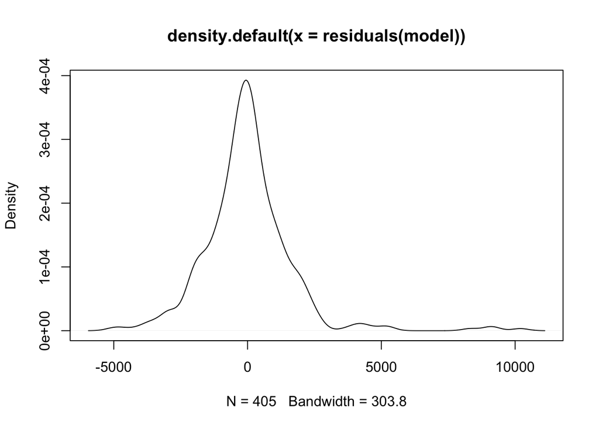

Next we want to explore whether the extremely high housing price in bay area is forcing people to live far away from the convenient locations and therefore having longer commute time.

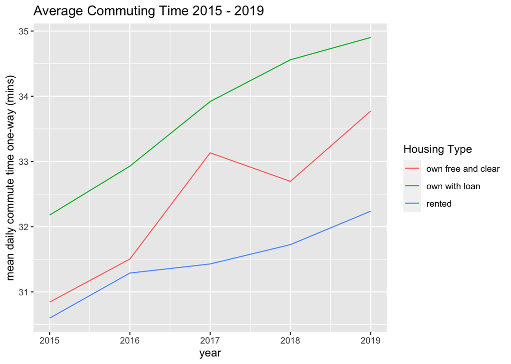

I first took a look at people’s commute time from 2015 to 2019. The commute time has been constantly increasing. It seems on average people who have their houses owned free and clear are closer to their work compared to those are still paying their debts. It makes a lot of sense because it is very possible that people who have paid off all their housing mortgages or bought their house in full cash are either those who have much higher income and wealth or their bought their houses long times ago, when housing prices were not crazily high at the time. We can also see in the following chart that the median housing price has also been increasing constantly, and the housing value for those are still on mortgages are higher than those owned free and clear.

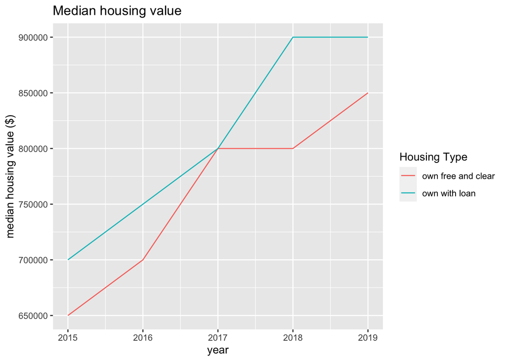

Next, I plotted maps to show the average commute time and the median housing price among census tracts. Not surprising at all, when the areas have lower housing prices, their average commute time will be higher. We can see that in the south bay areas, the census tracts that are closer to the silicon valley also have lower mean commute time but higher housing value. While in east bay area where housing are cheaper, the average commute time is a lot higher.

[interactive chart not shown]

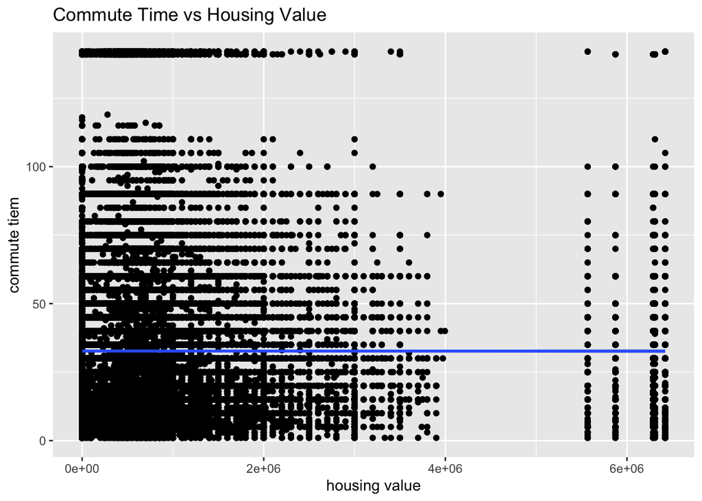

```
##
## Call:
## lm(formula = JWMNP ~ VALP, data = bay_pums_5yrs)
##
## Residuals:
##     Min      1Q  Median      3Q     Max
## -31.698 -17.694  -2.698  12.302 109.344
##
## Coefficients:
##               Estimate Std. Error t value Pr(>|t|)
## (Intercept)  3.270e+01  7.267e-02 449.934   <2e-16 ***
## VALP        -6.628e-09  6.722e-08  -0.099    0.921
## ---
## Signif. codes:  0 '***' 0.001 '**' 0.01 '*' 0.05 '.' 0.1 ' ' 1
##
## Residual standard error: 24.44 on 171350 degrees of freedom
## Multiple R-squared:  5.674e-08,  Adjusted R-squared:  -5.779e-06
## F-statistic: 0.009723 on 1 and 171350 DF,  p-value: 0.9215
```

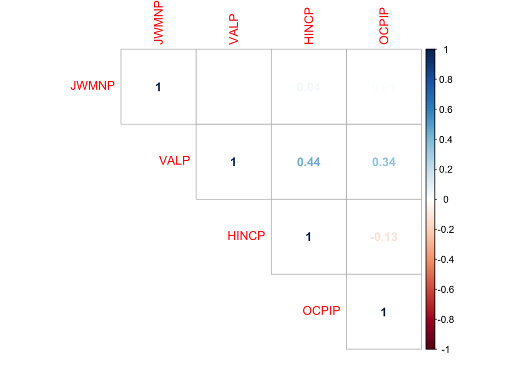

If we draw a correlation plot, we can see that the correlation coefficient for commute time (JWMNP) with all the other continuous variables (VALP - housing value, HINCP - household income, OCPIP - rent as percentage of monthly income) are very low.

If we build a multiple regression to include all the variables above along with year and PUMA, then we will get:

```
##
## Call:
## lm(formula = JWMNP ~ year + VALP + HINCP + OCPIP + PUMA, data = bay_pums_5yrs)
##
## Residuals:
##     Min      1Q  Median      3Q     Max
## -50.980 -16.138  -5.225  10.184 120.788
##
## Coefficients:
##               Estimate Std. Error t value Pr(>|t|)
## (Intercept) -9.528e+02  8.304e+01 -11.475  < 2e-16 ***
## year         4.876e-01  4.117e-02  11.843  < 2e-16 ***
## VALP        -3.917e-07  8.461e-08  -4.630 3.66e-06 ***
## HINCP        1.000e-05  4.464e-07  22.406  < 2e-16 ***
## OCPIP        1.703e-02  3.806e-03   4.474 7.68e-06 ***
## PUMA00102    9.443e-01  5.230e-01   1.806 0.070990 .
## PUMA00103    3.017e+00  5.645e-01   5.345 9.05e-08 ***
## PUMA00104    1.625e+00  6.146e-01   2.644 0.008199 **
## PUMA00105    2.381e+00  5.573e-01   4.272 1.94e-05 ***
## PUMA00106    3.121e+00  5.878e-01   5.310 1.10e-07 ***
## PUMA00107    3.432e+00  5.668e-01   6.054 1.41e-09 ***
## PUMA00108    4.817e+00  5.782e-01   8.332  < 2e-16 ***
## PUMA00109    2.532e+00  5.384e-01   4.702 2.58e-06 ***
## PUMA00110    3.960e+00  5.109e-01   7.752 9.13e-15 ***
## PUMA01301    3.283e+00  6.354e-01   5.167 2.39e-07 ***
## PUMA01302    6.884e+00  5.889e-01  11.691  < 2e-16 ***
## PUMA01303    2.458e+00  6.113e-01   4.020 5.81e-05 ***
## PUMA01304    2.443e+00  6.460e-01   3.782 0.000155 ***
## PUMA01305    6.260e+00  6.005e-01  10.425  < 2e-16 ***
## PUMA01306    4.844e+00  6.310e-01   7.677 1.63e-14 ***
## PUMA01307    9.590e+00  6.263e-01  15.313  < 2e-16 ***
## PUMA01308    1.399e+01  6.922e-01  20.210  < 2e-16 ***
## PUMA01309    1.313e+01  6.721e-01  19.532  < 2e-16 ***
## PUMA04101    2.196e+00  6.777e-01   3.240 0.001195 **
## PUMA04102    5.852e-01  5.980e-01   0.979 0.327816
## PUMA05500   -4.742e+00  5.545e-01  -8.551  < 2e-16 ***
## PUMA07501    2.527e+00  5.657e-01   4.467 7.95e-06 ***
## PUMA07502   -7.080e-01  5.945e-01  -1.191 0.233693
## PUMA07503   -3.791e-01  5.872e-01  -0.646 0.518518
## PUMA07504    2.354e+00  5.782e-01   4.071 4.69e-05 ***
```

[output cut: 20 more lines]

```
## PUMA08512    2.956e+00  5.897e-01   5.013 5.36e-07 ***
## PUMA08513    3.399e+00  6.070e-01   5.600 2.14e-08 ***
## PUMA08514   -2.873e+00  5.947e-01  -4.831 1.36e-06 ***
## PUMA09501    4.923e+00  5.756e-01   8.552  < 2e-16 ***
## PUMA09502    2.932e-01  5.871e-01   0.499 0.617514
## PUMA09503   -2.131e+00  6.064e-01  -3.515 0.000440 ***
## PUMA09701   -5.350e+00  5.506e-01  -9.717  < 2e-16 ***
## PUMA09702   -2.657e+00  5.992e-01  -4.434 9.27e-06 ***
## PUMA09703   -8.612e+00  5.635e-01 -15.283  < 2e-16 ***
## ---
## Signif. codes:  0 '***' 0.001 '**' 0.01 '*' 0.05 '.' 0.1 ' ' 1
##
## Residual standard error: 23.96 on 171293 degrees of freedom
## Multiple R-squared:  0.03909,    Adjusted R-squared:  0.03877
## F-statistic: 120.2 on 58 and 171293 DF,  p-value: < 2.2e-16
```

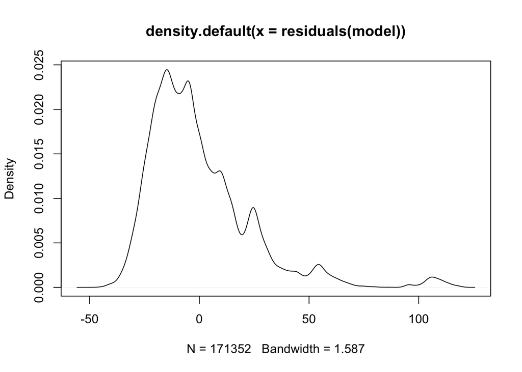

```
##
## Call:
## lm(formula = log(JWMNP) ~ year + VALP + HINCP + OCPIP + PUMA,
##     data = bay_pums_5yrs)
##
## Residuals:
##     Min      1Q  Median      3Q     Max
## -3.6570 -0.4612  0.0620  0.5197  2.1819
##
## Coefficients:
##               Estimate Std. Error t value Pr(>|t|)
## (Intercept) -2.059e+01  2.628e+00  -7.832 4.83e-15 ***
## year         1.176e-02  1.303e-03   9.024  < 2e-16 ***
## VALP        -1.562e-08  2.678e-09  -5.830 5.54e-09 ***
## HINCP        3.567e-07  1.413e-08  25.242  < 2e-16 ***
## OCPIP        5.464e-04  1.205e-04   4.536 5.74e-06 ***
## PUMA00102    6.990e-02  1.656e-02   4.222 2.42e-05 ***
## PUMA00103    1.499e-01  1.787e-02   8.391  < 2e-16 ***
## PUMA00104    9.789e-02  1.945e-02   5.032 4.86e-07 ***
## PUMA00105    9.472e-02  1.764e-02   5.369 7.93e-08 ***
## PUMA00106    1.318e-01  1.861e-02   7.082 1.42e-12 ***
## PUMA00107    1.514e-01  1.794e-02   8.437  < 2e-16 ***
## PUMA00108    2.059e-01  1.830e-02  11.253  < 2e-16 ***
## PUMA00109    1.302e-01  1.704e-02   7.640 2.19e-14 ***
## PUMA00110    5.598e-02  1.617e-02   3.462 0.000536 ***
## PUMA01301    9.600e-02  2.011e-02   4.773 1.81e-06 ***
## PUMA01302    2.358e-01  1.864e-02  12.648  < 2e-16 ***
## PUMA01303    3.850e-02  1.935e-02   1.990 0.046621 *
## PUMA01304    8.542e-02  2.045e-02   4.177 2.95e-05 ***
## PUMA01305    1.346e-01  1.901e-02   7.083 1.41e-12 ***
## PUMA01306    1.350e-01  1.997e-02   6.758 1.40e-11 ***
## PUMA01307    2.542e-01  1.983e-02  12.824  < 2e-16 ***
## PUMA01308    2.806e-01  2.191e-02  12.808  < 2e-16 ***
## PUMA01309    2.430e-01  2.127e-02  11.424  < 2e-16 ***
## PUMA04101    2.646e-02  2.145e-02   1.233 0.217418
## PUMA04102    1.017e-03  1.893e-02   0.054 0.957162
## PUMA05500   -2.589e-01  1.755e-02 -14.753  < 2e-16 ***
## PUMA07501    1.684e-01  1.791e-02   9.402  < 2e-16 ***
## PUMA07502    3.900e-02  1.882e-02   2.072 0.038246 *
## PUMA07503    1.810e-02  1.859e-02   0.974 0.330066
```

[output cut: 21 more lines]

```
## PUMA08512    1.550e-01  1.866e-02   8.306  < 2e-16 ***
## PUMA08513    1.871e-01  1.921e-02   9.738  < 2e-16 ***
## PUMA08514   -6.321e-03  1.882e-02  -0.336 0.737034
## PUMA09501    8.791e-02  1.822e-02   4.825 1.40e-06 ***
## PUMA09502   -5.961e-02  1.858e-02  -3.208 0.001339 **
## PUMA09503   -1.601e-01  1.919e-02  -8.341  < 2e-16 ***
## PUMA09701   -2.787e-01  1.743e-02 -15.994  < 2e-16 ***
## PUMA09702   -1.389e-01  1.897e-02  -7.322 2.45e-13 ***
## PUMA09703   -3.471e-01  1.784e-02 -19.460  < 2e-16 ***
## ---
## Signif. codes:  0 '***' 0.001 '**' 0.01 '*' 0.05 '.' 0.1 ' ' 1
##
## Residual standard error: 0.7584 on 171293 degrees of freedom
## Multiple R-squared:  0.04039,    Adjusted R-squared:  0.04007
## F-statistic: 124.3 on 58 and 171293 DF,  p-value: < 2.2e-16
```

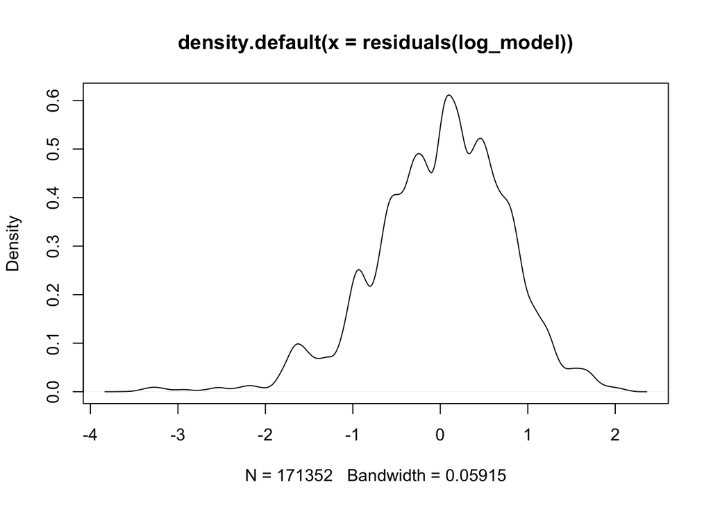

Although the density plot is not strictly normal, it looks less skewed than the last one, and log transformation seems to be appropriate here. The interpretation for the log transformed model is very similar to that of the original model, except that now the change for the commute time will be in percentage.